# Homework 3

**Author:** Benjamin Heindl

**Course:** IST 664

**Date:** November 20, 2023

# Sentiment Analysis Project

This project focuses on performing sentiment analysis on a dataset of tweets. We will import necessary libraries, preprocess the data, perform feature extraction using TF-IDF, train machine learning models, and evaluate their performance.

## Importing Necessary Libraries

Here we import all the required Python libraries that will be used throughout the project. This includes libraries for data manipulation, text processing, vectorization, model training, and evaluation.

```python
from collections import Counter
import pandas as pd
import numpy as np
import matplotlib.pyplot as plt
import seaborn as sns
from nltk.corpus import stopwords
from nltk.stem import WordNetLemmatizer
from nltk.tokenize import TweetTokenizer, word_tokenize, sent_tokenize
from nltk import pos_tag, RegexpParser
from nltk.sentiment import SentimentIntensityAnalyzer
from sklearn.feature_extraction.text import TfidfVectorizer, CountVectorizer
from sklearn.model_selection import train_test_split, cross_validate, GridSearchCV, KFold
from sklearn.naive_bayes import MultinomialNB
from sklearn.linear_model import LogisticRegression
from sklearn.metrics import accuracy_score, classification_report, confusion_matrix, precision_recall_fscore_support
import string
import warnings
warnings.filterwarnings("ignore", category=FutureWarning)
from IPython.display import display
from IPython.display import display_html
import seaborn as sns
import matplotlib.pyplot as plt
from wordcloud import WordCloud

# Uncomment these lines if you need to download these resources
# nltk.download('stopwords')
# nltk.download('wordnet')
# nltk.download('vader_lexicon')
# nltk.download('averaged_perceptron_tagger')
```

## Set Random Seed

Setting the random seed ensures reproducibility of the results. Any random operations will yield the same result each time the code is run.

```python
np.random.seed(42)
```

## Load Dataset

The dataset containing the tweets is loaded into a pandas DataFrame. The data includes tweets with corresponding sentiment labels that we will use for analysis.

```python
tweets_df = pd.read_csv('/Users/benjheindl/Desktop/Fall 2023/IST 664 Natural Language Processing/Homework/HW3/data/Tweets.csv')
```

## Preprocessing Text Data

Preprocessing is crucial in text analysis. We convert text to lowercase, remove punctuation, tokenize the text, remove stopwords, and lemmatize the tokens to reduce them to their base or root form.

```python
tokenizer = TweetTokenizer()
lemmatizer = WordNetLemmatizer()

def preprocess_text(text):
    text = text.lower()
    text = text.translate(str.maketrans('', '', string.punctuation))
    tokens = tokenizer.tokenize(text)
    tokens = [token for token in tokens if token not in set(stopwords.words('english'))]
    lemmatized_tokens = [lemmatizer.lemmatize(token) for token in tokens]
    return ' '.join(lemmatized_tokens)

tweets_df['preprocessed_text'] = tweets_df['text'].apply(preprocess_text)
```

## Feature Extraction with TF-IDF

We use the TF-IDF (Term Frequency-Inverse Document Frequency) vectorizer to convert the preprocessed text data into numerical feature vectors. This will be used as input for the machine learning models.

```python
tfidf_vectorizer = TfidfVectorizer(max_features=5000)
X_tfidf = tfidf_vectorizer.fit_transform(tweets_df['preprocessed_text'])
y = tweets_df['airline_sentiment'].apply(lambda x: 1 if x == 'positive' else 0)
```

## Model Training and Evaluation

We train two models: Naive Bayes and Logistic Regression. We use a train-test split for evaluation and employ GridSearchCV to find the best hyperparameters for the Naive Bayes classifier. After training, we evaluate the models using classification reports.

```
Best parameters set found on development set: {'alpha': 0.5}
Naive Bayes Classification Report:
              precision    recall  f1-score   support

           0       0.89      0.99      0.94      2469
           1       0.86      0.34      0.49       459

    accuracy                           0.89      2928
   macro avg       0.88      0.66      0.71      2928
weighted avg       0.88      0.89      0.87      2928

Logistic Regression Classification Report:
              precision    recall  f1-score   support

           0       0.91      0.99      0.95      2469
           1       0.89      0.49      0.63       459

    accuracy                           0.91      2928
   macro avg       0.90      0.74      0.79      2928
weighted avg       0.91      0.91      0.90      2928
```

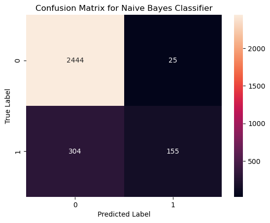

```python
X_train, X_test, y_train, y_test = train_test_split(X_tfidf, y, test_size=0.2, random_state=42)
nb_classifier = MultinomialNB()
parameters = {'alpha': [0.5, 1.0, 1.5, 2.0]}
clf = GridSearchCV(nb_classifier, parameters, cv=5, scoring='accuracy')
clf.fit(X_train, y_train)
print("Best parameters set found on development set:", clf.best_params_)

nb_model = MultinomialNB(alpha=clf.best_params_['alpha'])
nb_model.fit(X_train, y_train)
nb_predictions = nb_model.predict(X_test)

lr_model = LogisticRegression(random_state=42)
lr_model.fit(X_train, y_train)
lr_predictions = lr_model.predict(X_test)

print("Naive Bayes Classification Report:")
print(classification_report(y_test, nb_predictions))
print("Logistic Regression Classification Report:")
print(classification_report(y_test, lr_predictions))


# Visualization of the confusion matrix
sns.heatmap(confusion_matrix(y_test, nb_predictions), annot=True, fmt='d')
plt.title('Confusion Matrix for Naive Bayes Classifier')
plt.ylabel('True Label')
plt.xlabel('Predicted Label')
plt.show()
```

## Output Results to CSV

After analyzing the sentiments by author, we output the results to a CSV file for further analysis or sharing.

```python
sentiment_counts = tweets_df.groupby('name')['airline_sentiment'].value_counts().unstack().fillna(0)
sentiment_counts.columns = ['negative_count', 'neutral_count', 'positive_count']
sentiment_counts.reset_index(inplace=True)
output_csv_path = '/Users/benjheindl/Desktop/Fall 2023/IST 664 Natural Language Processing/Homework/HW3/data/sentiment_analysis_results.csv'
sentiment_counts.to_csv(output_csv_path, index=False)
print(f"CSV file saved to {output_csv_path}")
```

```
CSV file saved to /Users/benjheindl/Desktop/Fall 2023/IST 664 Natural Language Processing/Homework/HW3/data/sentiment_analysis_results.csv
```

## Phrase Extraction and Analysis

We extract meaningful phrases from the tweets using part-of-speech tagging and specific grammatical patterns. This helps us understand common language patterns associated with positive and negative sentiments.

```python
def extract_phrases(text, phrase_patterns):
    tagged_text = pos_tag(word_tokenize(text))
    cp = RegexpParser(phrase_patterns)
    tree = cp.parse(tagged_text)
    phrases = [" ".join(word for word, pos in subtree.leaves()) for subtree in tree.subtrees() if subtree.label() == 'PHRASE']
    return phrases

phrase_pattern = """
    PHRASE: {<RB.?>+<VB.?>+<JJ.?>+<NN.?>+}  # Pattern for adverb-verb-adjective-noun
            {<JJ.?>+<NN.?>+}                 # Pattern for adjective-noun
            {<RB.?>+<VB.?>+}                 # Pattern for adverb-verb
            {<JJ.*><NN.*>+}                  # Adjective followed by one or more nouns
            {<RB.*><VB.*>}                   # Adverb followed by a verb
"""
```

## Sentence-Level Sentiment Classification

```
Top 50 Positive vs Negative Adjective Phrases:
```

|  | Phrase | Count |
| --- | --- | --- |
| 0 | @ SouthwestAir | 287 |
| 1 | @ AmericanAir | 263 |
| 2 | @ JetBlue | 209 |
| 3 | @ USAirways | 78 |
| 4 | united thanks | 71 |
| 5 | @ JetBlue thanks | 64 |
| 6 | @ AmericanAir thanks | 55 |
| 7 | united thank | 46 |
| 8 | @ USAirways thanks | 46 |
| 9 | @ SouthwestAir thanks | 39 |
| 10 | united Thanks | 34 |
| 11 | @ SouthwestAir Thanks | 32 |
| 12 | @ JetBlue thank | 32 |
| 13 | @ SouthwestAir thank | 28 |
| 14 | united Thank | 26 |
| 15 | @ SouthwestAir Thank | 26 |
| 16 | @ AmericanAir Thanks | 26 |
| 17 | @ JetBlue Thanks | 24 |
| 18 | @ AmericanAir Thank | 24 |
| 19 | @ AmericanAir thank | 23 |
| 20 | great flight | 22 |
| 21 | Late Flight | 20 |
| 22 | @ JetBlue Thank | 20 |
| 23 | great job | 15 |
| 24 | united yes | 15 |
| 25 | quick response | 14 |
| 26 | @ USAirways Thanks | 14 |
| 27 | @ AmericanAir @ | 14 |
| 28 | first class | 13 |
| 29 | united please | 13 |
| 30 | Late Flightr | 13 |
| 31 | last night | 12 |
| 32 | @ AmericanAir please | 12 |
| 33 | @ AmericanAir Yes | 11 |
| 34 | best airline | 10 |
| 35 | good work | 10 |
| 36 | @ SouthwestAir Yes | 10 |
| 37 | @ SouthwestAir please | 10 |
| 38 | first time | 9 |
| 39 | Good luck | 9 |
| 40 | earlier flight | 9 |
| 41 | next time | 9 |
| 42 | great customer service | 9 |
| 43 | great service | 9 |
| 44 | @ AmericanAir yes | 9 |
| 45 | favorite airline | 8 |
| 46 | @ SouthwestAir @ | 8 |
| 47 | next flight | 8 |
| 48 | @ Imaginedragons | 8 |
| 49 | new CEO | 8 |

|  | Phrase | Count |
| --- | --- | --- |
| 0 | @ AmericanAir | 280 |
| 1 | @ SouthwestAir | 211 |
| 2 | @ JetBlue | 184 |
| 3 | @ USAirways | 70 |
| 4 | Late Flight | 51 |
| 5 | worst airline | 31 |
| 6 | Late Flightr | 25 |
| 7 | bad weather | 25 |
| 8 | poor customer service | 17 |
| 9 | @ USAirways flight | 17 |
| 10 | last night | 16 |
| 11 | delayed flight | 16 |
| 12 | worst customer service | 16 |
| 13 | @ AmericanAir @ | 15 |
| 14 | united flight | 12 |
| 15 | next flight | 12 |
| 16 | mechanical issues | 12 |
| 17 | @ JetBlue flight | 12 |
| 18 | @ AmericanAir @ USAirways | 11 |
| 19 | first flight | 10 |
| 20 | @ SouthwestAir flight | 10 |
| 21 | other airlines | 9 |
| 22 | mechanical problems | 9 |
| 23 | last week | 9 |
| 24 | terrible customer service | 9 |
| 25 | Cancelled Flightlations | 9 |
| 26 | worst experience | 9 |
| 27 | American http | 9 |
| 28 | @ AmericanAir flight | 9 |
| 29 | @ AmericanAir Flight | 9 |
| 30 | united No | 8 |
| 31 | terrible service | 8 |
| 32 | last flight | 8 |
| 33 | empty seats | 8 |
| 34 | Terrible customer service | 8 |
| 35 | Terrible service | 7 |
| 36 | checked bag | 7 |
| 37 | new flight | 7 |
| 38 | united Flight | 7 |
| 39 | worst service | 7 |
| 40 | reFlight Booking Problems | 7 |
| 41 | earlier flight | 7 |
| 42 | wait time | 7 |
| 43 | @ SouthwestAir Cancelled | 7 |
| 44 | leading cause | 6 |
| 45 | “ @ | 6 |
| 46 | bad experience | 6 |
| 47 | entire day | 6 |
| 48 | terrible experience | 6 |
| 49 | horrible customer service | 6 |

```
Top 50 Positive vs Negative Adverb Phrases:
```

|  | Phrase | Count |
| --- | --- | --- |
| 0 | @ united | 115 |
| 1 | n't get | 28 |
| 2 | n't have | 24 |
| 3 | just want | 23 |
| 4 | not be | 17 |
| 5 | n't be | 12 |
| 6 | n't worry | 11 |
| 7 | n't miss | 10 |
| 8 | n't know | 9 |
| 9 | n't want | 9 |
| 10 | n't wait | 8 |
| 11 | n't think | 8 |
| 12 | not get | 8 |
| 13 | n't find | 7 |
| 14 | never been | 7 |
| 15 | n't let | 7 |
| 16 | just sent | 6 |
| 17 | n't say | 6 |
| 18 | just landed | 6 |
| 19 | n't need | 6 |
| 20 | really appreciate | 6 |
| 21 | not working | 5 |
| 22 | just got | 5 |
| 23 | n't believe | 5 |
| 24 | n't give | 5 |
| 25 | n't do | 5 |
| 26 | never got | 5 |
| 27 | n't understand | 5 |
| 28 | just lost | 5 |
| 29 | much appreciated | 5 |
| 30 | never fly | 5 |
| 31 | not getting | 5 |
| 32 | just hope | 5 |
| 33 | just had | 5 |
| 34 | just need | 5 |
| 35 | n't been | 5 |
| 36 | n't go | 5 |
| 37 | n't bother | 5 |
| 38 | currently using | 4 |
| 39 | n't Cancelled | 4 |
| 40 | not Cancelled | 4 |
| 41 | n't leave | 4 |
| 42 | n't make | 4 |
| 43 | now waiting | 4 |
| 44 | n't seem | 4 |
| 45 | finally got | 4 |
| 46 | never fails | 4 |
| 47 | never had | 4 |
| 48 | Much appreciated | 4 |
| 49 | Well done | 4 |

|  | Phrase | Count |
| --- | --- | --- |
| 0 | @ united | 103 |
| 1 | n't get | 44 |
| 2 | n't help | 40 |
| 3 | n't want | 33 |
| 4 | n't have | 30 |
| 5 | n't care | 28 |
| 6 | n't be | 23 |
| 7 | n't let | 16 |
| 8 | n't do | 16 |
| 9 | not be | 14 |
| 10 | ever had | 14 |
| 11 | n't make | 13 |
| 12 | n't like | 11 |
| 13 | just Cancelled | 11 |
| 14 | just got | 11 |
| 15 | still have | 10 |
| 16 | not want | 9 |
| 17 | not have | 9 |
| 18 | not get | 9 |
| 19 | n't find | 8 |
| 20 | n't believe | 8 |
| 21 | n't take | 7 |
| 22 | still waiting | 7 |
| 23 | just want | 7 |
| 24 | n't seem | 7 |
| 25 | n't know | 7 |
| 26 | now delayed | 6 |
| 27 | now have | 6 |
| 28 | not getting | 6 |
| 29 | not helping | 6 |
| 30 | then Cancelled | 6 |
| 31 | already Cancelled | 6 |
| 32 | n't fly | 6 |
| 33 | n't see | 6 |
| 34 | n't allow | 6 |
| 35 | not being | 6 |
| 36 | n't understand | 5 |
| 37 | n't work | 5 |
| 38 | ever experienced | 5 |
| 39 | now lost | 5 |
| 40 | now sitting | 5 |
| 41 | not resolved | 5 |
| 42 | now been | 5 |
| 43 | n't been | 5 |
| 44 | n't go | 5 |
| 45 | n't working | 5 |
| 46 | not help | 5 |
| 47 | not make | 5 |
| 48 | never been | 5 |
| 49 | never got | 5 |

```
Top 50 Positive vs Negative Verb Phrases:
```

|  | Phrase | Count |
| --- | --- | --- |
| 0 | Cancelled Flightled | 20 |
| 1 | get home | 16 |
| 2 | Please help | 15 |
| 3 | need help | 14 |
| 4 | get help | 9 |
| 5 | connecting flight | 9 |
| 6 | Cancelled Flight | 8 |
| 7 | taking care | 8 |
| 8 | taken care | 8 |
| 9 | take care | 8 |
| 10 | please help | 8 |
| 11 | Cancelled Flighted | 7 |
| 12 | please passengers | 7 |
| 13 | go home | 6 |
| 14 | took care | 6 |
| 15 | do something | 6 |
| 16 | have someone | 6 |
| 17 | u help | 6 |
| 18 | snow removal method | 5 |
| 19 | do anything | 5 |
| 20 | get tickets | 5 |
| 21 | amazing customer service | 4 |
| 22 | united i | 4 |
| 23 | email address please | 4 |
| 24 | treat customers | 4 |
| 25 | paying customers | 4 |
| 26 | Flightled flights | 4 |
| 27 | be home | 4 |
| 28 | Cancelled Flightlations | 4 |
| 29 | hold flight | 4 |
| 30 | Need help | 4 |
| 31 | @ JetBlue | 4 |
| 32 | ARE THE BEST | 4 |
| 33 | won ’ t | 3 |
| 34 | guys rock | 3 |
| 35 | united Will | 3 |
| 36 | got Cancelled Flightled | 3 |
| 37 | becoming pilots | 3 |
| 38 | love http | 3 |
| 39 | Flightled flight | 3 |
| 40 | @ Delta | 3 |
| 41 | miss connection | 3 |
| 42 | ARE THE BEST AIRWAYS | 3 |
| 43 | @ AmericanAir | 3 |
| 44 | getting home | 3 |
| 45 | flying experience | 2 |
| 46 | have flights | 2 |
| 47 | improve service | 2 |
| 48 | called United | 2 |
| 49 | contact customer care | 2 |

|  | Phrase | Count |
| --- | --- | --- |
| 0 | Cancelled Flightled | 126 |
| 1 | Cancelled Flight | 59 |
| 2 | Cancelled Flighted | 58 |
| 3 | connecting flight | 19 |
| 4 | get home | 15 |
| 5 | appease passengers | 15 |
| 6 | Flightled flight | 10 |
| 7 | having trouble | 9 |
| 8 | got Cancelled | 9 |
| 9 | flying experience | 8 |
| 10 | lost bag | 8 |
| 11 | Cancelled Flightlations | 7 |
| 12 | delayed flight | 6 |
| 13 | delayed flights | 6 |
| 14 | lost baggage | 6 |
| 15 | Flightled yesterday | 6 |
| 16 | is flight | 5 |
| 17 | Booking Problems | 5 |
| 18 | reFlight Booking Problems | 5 |
| 19 | Cancelled Flight online | 5 |
| 20 | Flightled flights | 5 |
| 21 | Flightled today | 5 |
| 22 | paying customers | 5 |
| 23 | been Cancelled Flighted | 5 |
| 24 | @ AmericanAir | 4 |
| 25 | are flights | 4 |
| 26 | connecting flights | 4 |
| 27 | was flight | 4 |
| 28 | Cancelled Flightations | 4 |
| 29 | lost luggage | 4 |
| 30 | got Cancelled Flightled | 4 |
| 31 | Cancelled Flights | 4 |
| 32 | Cancelled Flight flight | 4 |
| 33 | Cancelled Flighting flights | 4 |
| 34 | worst experience | 4 |
| 35 | did nothing | 3 |
| 36 | u help | 3 |
| 37 | did DM | 3 |
| 38 | checked bag | 3 |
| 39 | miss connection | 3 |
| 40 | do anything | 3 |
| 41 | miss connections | 3 |
| 42 | Flighted flight | 3 |
| 43 | murdering ways | 3 |
| 44 | missing luggage | 3 |
| 45 | was rude | 3 |
| 46 | change flights | 3 |
| 47 | getting Cancelled Flighted | 3 |
| 48 | 'm nuts | 3 |
| 49 | change flight | 3 |

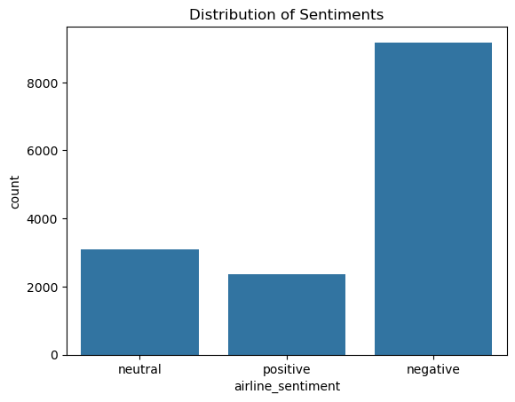

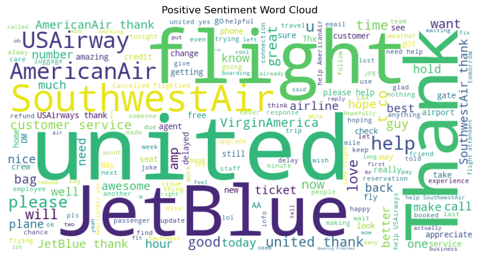

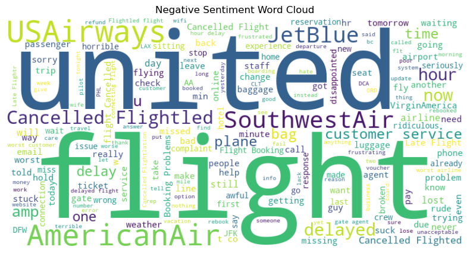

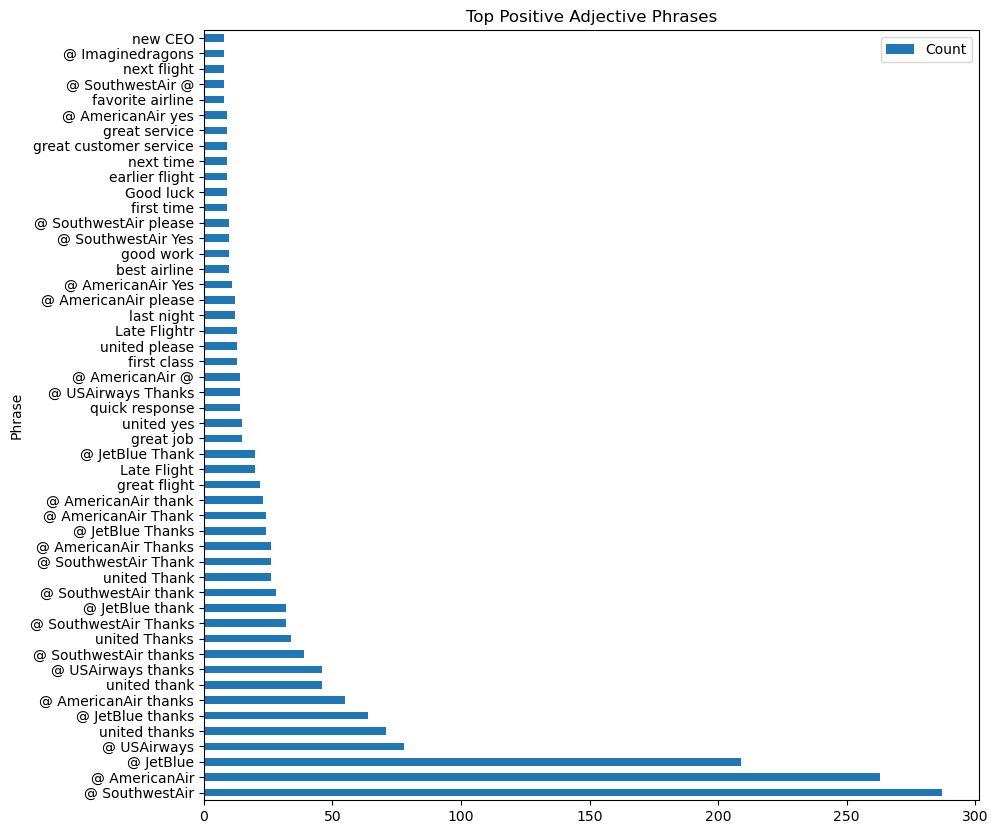

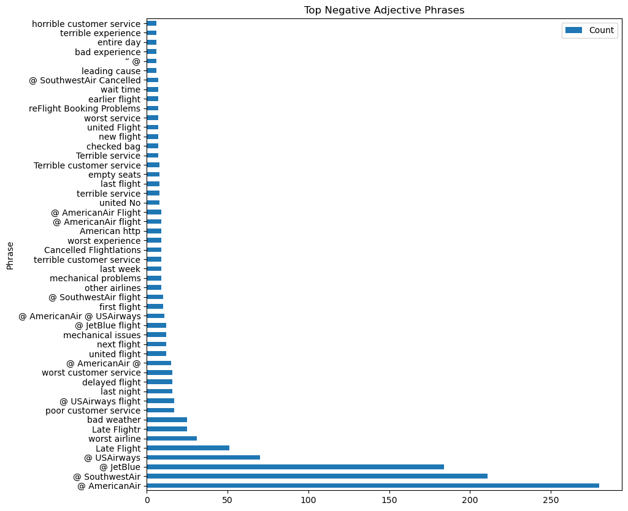

```python
from collections import Counter
from nltk import pos_tag, RegexpParser
from nltk.tokenize import word_tokenize
import pandas as pd
from IPython.display import display

# Define the function to extract specific phrase patterns
def extract_phrases_by_type(text, phrase_pattern):
    tagged_text = pos_tag(word_tokenize(text))
    cp = RegexpParser(phrase_pattern)
    tree = cp.parse(tagged_text)
    phrases_by_type = {
        'ADJP': [],
        'ADVP': [],
        'VP': []
    }
    for subtree in tree.subtrees():
        if subtree.label() in phrases_by_type:
            phrase = " ".join(word for word, pos in subtree.leaves())
            phrases_by_type[subtree.label()].append(phrase)
    return phrases_by_type

# Define the patterns for adjective, adverb, and verb phrases
phrase_patterns = """
    ADJP: {<JJ.*><NN.*>+}  # Adjective followed by one or more nouns
    ADVP: {<RB.*><VB.*>}   # Adverb followed by a verb
    VP:   {<VB.*><NN.*>+}  # Verb followed by one or more nouns
"""

# Initialize the phrase counters for each type
positive_phrases_by_type = {
    'ADJP': Counter(),
    'ADVP': Counter(),
    'VP': Counter()
}

negative_phrases_by_type = {
    'ADJP': Counter(),
    'ADVP': Counter(),
    'VP': Counter()
}


# Initialize VADER sentiment intensity analyzer
sid = SentimentIntensityAnalyzer()


tweets_df['sentences'] = tweets_df['text'].apply(sent_tokenize)


# Classify each sentence as positive or negative based on the compound score
positive_sentences = []
negative_sentences = []
all_sentences = [sentence for sentences_list in tweets_df['sentences'] for sentence in sentences_list]


for sentence in all_sentences:
    if sid.polarity_scores(sentence)['compound'] >= 0.05:
        positive_sentences.append(sentence)
    elif sid.polarity_scores(sentence)['compound'] <= -0.05:
        negative_sentences.append(sentence)


# Extract phrases from positive and negative sentences
for sentence in positive_sentences:
    phrases = extract_phrases_by_type(sentence, phrase_patterns)
    for ptype in phrases:
        positive_phrases_by_type[ptype].update(phrases[ptype])

for sentence in negative_sentences:
    phrases = extract_phrases_by_type(sentence, phrase_patterns)
    for ptype in phrases:
        negative_phrases_by_type[ptype].update(phrases[ptype])

# Get the top 50 phrases for each type
top_positive_adjp = positive_phrases_by_type['ADJP'].most_common(50)
top_positive_advp = positive_phrases_by_type['ADVP'].most_common(50)
top_positive_vp = positive_phrases_by_type['VP'].most_common(50)

top_negative_adjp = negative_phrases_by_type['ADJP'].most_common(50)
top_negative_advp = negative_phrases_by_type['ADVP'].most_common(50)
top_negative_vp = negative_phrases_by_type['VP'].most_common(50)

# Function to convert phrases to DataFrame
def phrases_to_df(top_phrases):
    return pd.DataFrame(top_phrases, columns=['Phrase', 'Count'])

# Convert to DataFrames
positive_adjp_df = phrases_to_df(top_positive_adjp)
positive_advp_df = phrases_to_df(top_positive_advp)
positive_vp_df = phrases_to_df(top_positive_vp)

negative_adjp_df = phrases_to_df(top_negative_adjp)
negative_advp_df = phrases_to_df(top_negative_advp)
negative_vp_df = phrases_to_df(top_negative_vp)


# Function to display dataframes side by side
def display_side_by_side(*args):
    html_str = ''
    for df in args:
        html_str += df.to_html()
    display_html(html_str.replace('table','table style="display:inline"'), raw=True)

# Display the tables side by side
print("Top 50 Positive vs Negative Adjective Phrases:")
display_side_by_side(positive_adjp_df, negative_adjp_df)
print("Top 50 Positive vs Negative Adverb Phrases:")
display_side_by_side(positive_advp_df, negative_advp_df)
print("Top 50 Positive vs Negative Verb Phrases:")
display_side_by_side(positive_vp_df, negative_vp_df)

# Visualize the sentiment distribution
sns.countplot(x='airline_sentiment', data=tweets_df)
plt.title('Distribution of Sentiments')
plt.show()


# Let's use the positive_sentences and negative_sentences that we defined and for word clouds.


# Word Cloud for Positive Sentiments
positive_text = ' '.join(positive_sentences)
positive_wordcloud = WordCloud(width=800, height=400, background_color='white').generate(positive_text)
plt.figure(figsize=(10, 5))
plt.imshow(positive_wordcloud, interpolation='bilinear')
plt.axis('off')
plt.title('Positive Sentiment Word Cloud')
plt.show()

# Word Cloud for Negative Sentiments
negative_text = ' '.join(negative_sentences)
negative_wordcloud = WordCloud(width=800, height=400, background_color='white').generate(negative_text)
plt.figure(figsize=(10, 5))
plt.imshow(negative_wordcloud, interpolation='bilinear')
plt.axis('off')
plt.title('Negative Sentiment Word Cloud')
plt.show()

# Phrase Frequency Bar Chart for Positive Adjective Phrases
positive_adjp_df.plot(kind='barh', x='Phrase', y='Count', figsize=(10, 10), title='Top Positive Adjective Phrases')

# Phrase Frequency Bar Chart for Negative Adjective Phrases
negative_adjp_df.plot(kind='barh', x='Phrase', y='Count', figsize=(10, 10), title='Top Negative Adjective Phrases')
```

## Cross-validation and Evaluation Metrics

We use K-Fold cross-validation to evaluate our model's performance more robustly. The precision, recall, and F1-score are computed for a comprehensive assessment of the model's predictive power.

```python
label_encoding = {'negative': 0, 'neutral': 1, 'positive': 2}
y_encoded = np.array([label_encoding[label] for label in y_sentences])

def cross_validate_model(clf, X, y, n_splits=5):
    kf = KFold(n_splits=n_splits, shuffle=True, random_state=42)
    precisions = []
    recalls = []
    f1_scores = []

    for train_index, test_index in kf.split(X):
        X_train, X_test = X[train_index], X[test_index]
        y_train, y_test = y[train_index], y[test_index]
        clf.fit(X_train, y_train)
        predictions = clf.predict(X_test)
        precision, recall, f1, _ = precision_recall_fscore_support(y_test, predictions, average='weighted')
        precisions.append(precision)
        recalls.append(recall)
        f1_scores.append(f1)

    return {
        'precision': np.mean(precisions),
        'recall': np.mean(recalls),
        'f1': np.mean(f1_scores)
    }

evaluation_results = cross_validate_model(nb_classifier, X_sentences, y_encoded, n_splits=5)
print("Cross-validation results:", evaluation_results)
```

[output not shown]